# Assignment 1 - ESM 244

Author

Meet Muchhala

# Amphibian Data Analysis Report

## Objective

The aim of this exploratory analysis is to visualize data on the mountain yellow-legged frog (Rana muscosa) from the Sierra Amphibians dataset. We aim to provide meaningful insights into the population trends of different life stages of these frogs across years and highlight the distribution of adult and subadult frogs in the top five lakes.

## About the dataset

From the Environmental Data Initiative repository: “The Sierra Lakes Inventory Project (SLIP) was a research endeavor that ran from 1995-2002 and has supported research and management of Sierra Nevada aquatic ecosystems and their terrestrial interfaces. We described the physical characteristics of and surveyed aquatic communities for >8,000 lentic water bodies in the southern Sierra Nevada, including lakes, ponds, marshes, and meadows.”

## Analysis

### Initializing the data and libraries

We began by loading the necessary libraries and importing the Sierra Amphibians dataset. This dataset contains information about the count of yellow-legged frogs at various life stages across different water bodies.

```r
library(tidyverse)
library(readxl)
library(cowplot)
library(patchwork)
library(here)
library(lubridate)
library(dplyr)
```

```r
sierra_amp_df <- read_excel(here("data", "sierra_amphibians.xlsx"))
```

### Graph 1: Total Yellow-Legged Frog Count Each Year by Life Stage

The first graph depicts the total count of mountain yellow-legged frogs observed each year, categorized by life stage (excluding ‘EggMass’). To achieve this, we first started with selecting the parameters (Survery Date, Amphibian Species, Amphibian Life Stage). Then, we filtered the date to exclude Eggmass from the life stage and finally we converted the date to the corresponding year. Grouped the data by year and life stage, we calculated the total counts. The resulting graph provides a comprehensive overview of population dynamics over the study period.

```r
ramu_df <- sierra_amp_df %>%
  select(survey_date, amphibian_species, amphibian_life_stage, amphibian_state, lake_id ) %>%
  filter(amphibian_life_stage != "EggMass" & amphibian_species == "RAMU")

ramu_df$survey_date <- lubridate::year(ramu_df$survey_date) # Changed the date format to year
```

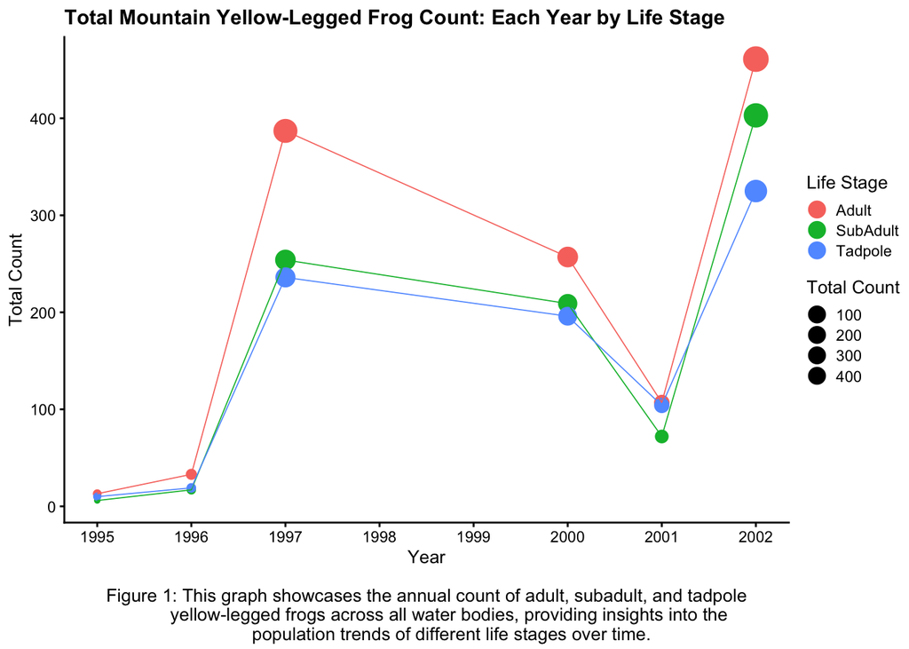

```r
## Filtering and grouping to get total count of each life stage counts

ramu_count <- ramu_df %>%
    mutate(amphibian_life_stage = as.factor(amphibian_life_stage)) %>%
    group_by(survey_date, amphibian_life_stage) %>%
    summarize(total_count = n())

## Graph 1 for combined plot without caption and legend on top

graph1 <- ggplot(ramu_count, aes(survey_date, total_count,
          color = amphibian_life_stage, size = total_count)) +
          geom_point() + geom_line(size = .3) +
          scale_x_continuous(n.breaks=8) +
          theme_cowplot(10) +
          labs(x = "Year", y = "Total Count", fill = "Life Stage") +
          theme(legend.position = 'null') +
          ggtitle("Total Mountain Yellow-Legged Frog Count: Each Year by Life Stage") +
   geom_label(label="Adult", x=1998, y=350, color = "black", size=3) +
  geom_label(label="SubAdult", x=1998, y=250, color = "black", size=3) +
  geom_label(label="Tadpole", x=1998, y=210, color = "black", size=3)

## Final graph for individual representation

final_graph1 <- ggplot(ramu_count, aes(survey_date, total_count,
          color = amphibian_life_stage, size = total_count)) +
          geom_point() + geom_line(size = .3) +
          scale_x_continuous(n.breaks=8) +
          theme_cowplot(10) +
          labs(x = "Year", y = "Total Count", fill = "Life Stage", caption = "Figure 1: This graph showcases the annual count of adult, subadult, and tadpole
          yellow-legged frogs across all water bodies, providing insights into the
          population trends of different life stages over time." ) +
  theme(plot.caption = element_text(size = 10, hjust = 0.5, vjust = 0, margin = margin(t = 10))) +
          theme(legend.position = "right") +
          guides(color = guide_legend(title = "Life Stage",
          override.aes = list(size = 4)), size = guide_legend(title = "Total Count",                     override.aes = list(color = "black", size = 4))) +
          ggtitle("Total Mountain Yellow-Legged Frog Count: Each Year by Life Stage")

final_graph1
```

### Graph 2: Total Adult and Subadult Frog Counts in Top 5 Lakes

The second graph focuses on the combined count of adult and subadult yellow-legged frogs in the five lakes with the highest observed counts. We reformatted the lake ID for better readability, reordered the lakes by total frog counts, and visualized the distribution.

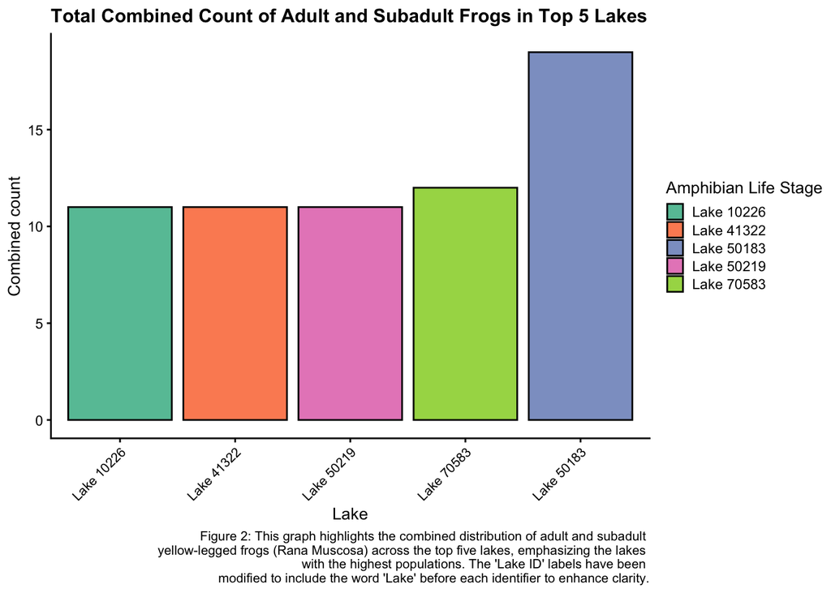

```r
## Filtering and Grouping to determine top 5 lakes

top5lakes_count <- ramu_df %>%
  filter(amphibian_life_stage %in% c("Adult", "SubAdult")) %>%
  group_by(lake_id) %>%
  summarise(total_count = n()) %>%
  arrange(desc(total_count)) %>%
  slice_head(n = 5)

## Adding a column for life stages as combined

top5lakes_count$amphibian_life_stage <- "Combined Adults & SubAdults"

## Adding 'Lake' ahead of each lake id for the purpose of representation

top5lakes_count$lake_id <- str_c("Lake ", top5lakes_count$lake_id)

## Graph 2 without caption for combined graph and legend on top

graph2 <- ggplot(top5lakes_count, aes(x = reorder(lake_id, total_count), y = total_count, fill = lake_id)) +
  geom_col(position = "dodge", color = "black") +
  labs(x = "Lake",
       y = "Combined count",
       fill = "Amphibian Life Stage") +
  theme_cowplot(10) +
  ggtitle("Total Combined Count of Adult and Subadult Frogs in Top 5 Lakes") +
  theme(legend.position = 'none') +
  scale_fill_brewer(palette = "Set2")

  ## Graph 2 with caption for individual representation

final_graph2 <- ggplot(top5lakes_count, aes(x = reorder(lake_id, total_count), y = total_count, fill = lake_id)) +
  geom_col(position = "dodge", color = "black") +
  labs(x = "Lake",
       y = "Combined count",
       fill = "Amphibian Life Stage", caption = "Figure 2: This graph highlights the combined distribution of adult and subadult
       yellow-legged frogs (Rana Muscosa) across the top five lakes, emphasizing the lakes
       with the highest populations. The 'Lake ID' labels have been
       modified to include the word 'Lake' before each identifier to enhance clarity." ) +
  theme(plot.caption = element_text(size = 10, hjust = 1, vjust = 0, margin = margin(t = 10))) +
  theme_cowplot(10) +
  ggtitle("Total Combined Count of Adult and Subadult Frogs in Top 5 Lakes") +
  theme(legend.position = "right",
        axis.text.x = element_text(size = 8, angle = 45, hjust = 1)) +
  scale_fill_brewer(palette = "Set2")

final_graph2
```

### Combined graphs

Both graphs were combined into a single compound figure for enhancing representation. This allows for a more clear of the data, facilitating a comparative analysis of the population trends and lake-specific distributions.

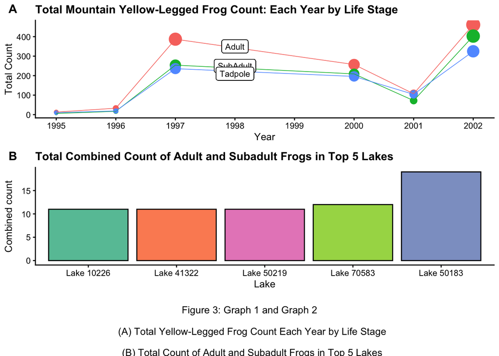

```r
?plot_grid

# Combine graph1 and graph2 vertically
combined_graphs <- plot_grid(graph1, graph2, ncol = 1, labels = c('A', 'B'), label_size = 12,
                              align = 'v', hjust = -1) +
  labs(caption = "Figure 3: Graph 1 and Graph 2\n
  (A) Total Yellow-Legged Frog Count Each Year by Life Stage\n
  (B) Total Count of Adult and Subadult Frogs in Top 5 Lakes") +
  theme_nothing() +
  theme(
    plot.caption = element_text(size = 10, hjust = 0.5, vjust = 0, margin = margin(t = 10))
  )


combined_graphs
```

## References

- Knapp, R.A., C. Pavelka, E.E. Hegeman, and T.C. Smith. 2020. The Sierra Lakes Inventory Project: Non-Native fish and community composition of lakes and ponds in the Sierra Nevada, California ver 2. Environmental Data Initiative. https://doi.org/10.6073/pasta/d835832d7fd00d9e4466e44eea87fab3